# Story 1 - Infrastructure

DATA 608: Knowledge and Visual Analytics

Jeff Parks

```r
data <- read_csv('https://raw.githubusercontent.com/jefedigital/cuny-data-608-visual-analytics/main/assignments/week-01/story-1-infrastructure/story-1-data.csv')
```

## Introduction

The provided contained data on the present allocation of the Infrastructure Investment and Jobs Act funding by State and Territory.

This story explores the following questions:

- Is the allocation equitable based on the population of each of the States and Territories, or is bias apparent?
- Does the allocation favor the political interests of the Biden administration?

## Data Preparation

I brought in several additional data sources to help provide context such as Population, Gross Domestic Product (GDP) and Poverty Level by state. For simplicity I pulled these data points together in a single data table in excel and created some composites (such as per-capita and ranks.)

The resulting variables were:

- state
- biden_win (flag 0 or 1)
- investment_b (total investment in billions)
- pop (total population)
- investment_pc (investment_ per capita_b / pop)
- poverty_lvl (percentage of pop below poverty line)
- area_sqkm (total land area in sq km)
- gdp_m (state gdp in millions)
- gdp_pc (gdp / pop)
- gdp_rank (gdp ranked hi-lo 1-51)
- ipc_rank (investment_pc ranked hi-lo 1-51)
- gdp_pc_rank (gdp_pc ranked hi-lo 1-51)
- poverty_rank (poverty_level ranked lo-hi 1-51)

## Analysis

First, we can look at the total investment, grouped by states where Biden won or lost in the 2020 Presidential election. At first glance, there might appear to be disparity, as 55% of total infrastructure funds went to so-called Democratic ‘Blue States’.

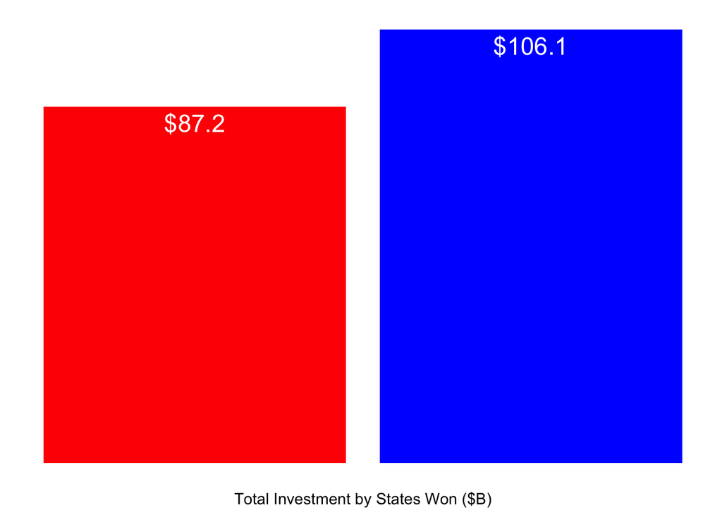

```r
df_sum <- data %>%
  select(c(investment_b, biden_win)) %>%
  group_by(biden_win) %>%
  summarize(total_investment_b = sum(investment_b))

plot_sum <- df_sum %>%
  ggplot(aes(x=biden_win, y=total_investment_b, fill=factor(biden_win))) +
  geom_bar(stat='identity', position='identity') +
  scale_fill_manual(values = c('red','blue')) +
  labs(x = "Total Investment by States Won ($B)", y = "Total Investment ($B)") +
  geom_text(aes(label = paste0('$', round(total_investment_b,2))),
            color='white', position = position_nudge(y = -4), hjust = .5, size=6) +
  theme_minimal() +
  theme(
    plot.title = element_blank(),
    axis.text.x = element_blank(),
    axis.title.y = element_blank(),
    axis.text.y = element_blank(),
    panel.grid.major = element_blank(),
    panel.grid.minor = element_blank(),
    legend.position = 'none'
  )

plot_sum
```

However when we start to look at state-by-state results and per-capita rates, a different picture seems to emerge. Looking at the bar graph on the right, only half of the Top 20 states ranked by Investment per Capital went for the Democrats in 2020.

Perhaps there are some other useful criteria to understand the allocation of Infrastructure funds. The graph on the left shows the rank of the state in terms of GDP. Most of the states that received the highest level of funding were low- or mid-ranked for GDP, which suggest that financial need may have been more of a factor than political alignment.

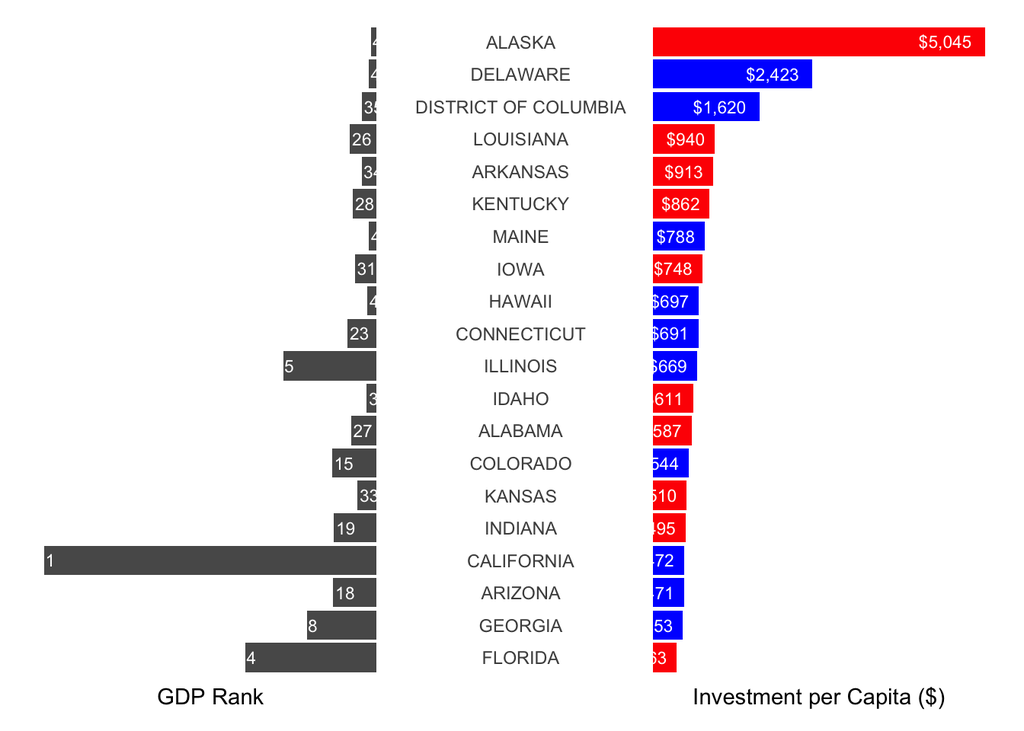

```r
df_top <- data %>%
  select(c('region','biden_win','investment_pc','gdp_m','area_sqkm','road_miles','gdp_rank', 'poverty_lvl', 'poverty_rank')) %>%
  mutate(region = factor(region, levels = region[order(investment_pc)]),
         gdp_m = round(gdp_m/1000,1),
         investment_pc = round(investment_pc,0)) %>%
  slice(1:20)

inv_rank_right <- df_top %>%
  ggplot(aes(x = region, y = investment_pc, fill=factor(biden_win))) +
  geom_bar(stat = "identity", position = "identity") +
  scale_fill_manual(values = c('red','blue')) +
  coord_flip() +
  scale_y_continuous(labels = abs) +
  labs(x = "State", y = "Investment per Capita ($)") +
  geom_text(aes(label = paste0('$', scales::comma(investment_pc))),
            color='white', hjust=1.25, size=3) +
  theme_minimal() +
  theme(
    plot.title = element_blank(),
    axis.text.x = element_blank(),
    axis.title.y = element_blank(),
    panel.grid.major = element_blank(),
    panel.grid.minor = element_blank(),
    legend.position = 'none',
    axis.text.y = element_text(hjust = 0.5),
    plot.margin = margin(5.5, 5.5, 5.5, 5.5)
  )

gdp_rank_left <- df_top %>%
ggplot(aes(x = region, y = -gdp_m)) +
  geom_bar(stat = "identity", position = "identity") +
  coord_flip() +
  scale_y_continuous(labels = abs) +
  labs(x = "State", y = "GDP Rank") +
  geom_text(aes(label = paste0(gdp_rank)),
    color='white', position = position_nudge(y = 3), hjust = -0.1, size=3) +
  theme_minimal() +
  theme(
    plot.title = element_blank(),
    axis.text.x = element_blank(),
    axis.title.y = element_blank(),
    axis.text.y = element_blank(),
    panel.grid.major = element_blank(),
    panel.grid.minor = element_blank(),
    legend.position = 'none'
  )

gdp_rank_left + inv_rank_right
```

Similarly, we can examine the relationship between funding levels and other economic indicators, such as the percentage of a state’s population living below the Federal Poverty Line. Here the relationship is not quite as strong, although four of some of the most impoverished states appear in the Top 20 for funding:

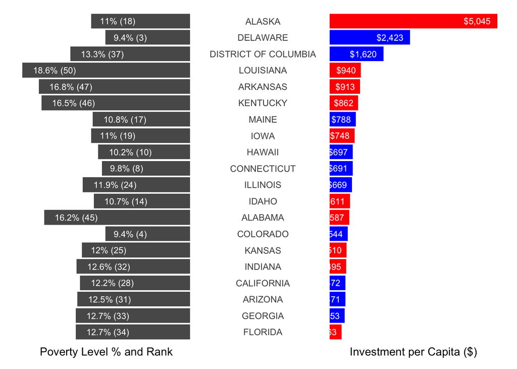

```r
poverty_rank_left <- df_top %>%
  ggplot(aes(x = region, y = -poverty_lvl)) +
  geom_bar(stat = "identity", position = "identity") +
  coord_flip() +
  scale_y_continuous(labels = abs) +
  labs(x = "State", y = "Poverty Level % and Rank") +
  geom_text(aes(label = paste0(poverty_lvl, '% (', poverty_rank, ')')),
            color='white', hjust = -0.25, size=3) +
  theme_minimal() +
  theme(
    plot.title = element_blank(),
    axis.text.x = element_blank(),
    axis.title.y = element_blank(),
    axis.text.y = element_blank(),
    panel.grid.major = element_blank(),
    panel.grid.minor = element_blank(),
    legend.position = 'none'
  )

poverty_rank_left + inv_rank_right
```

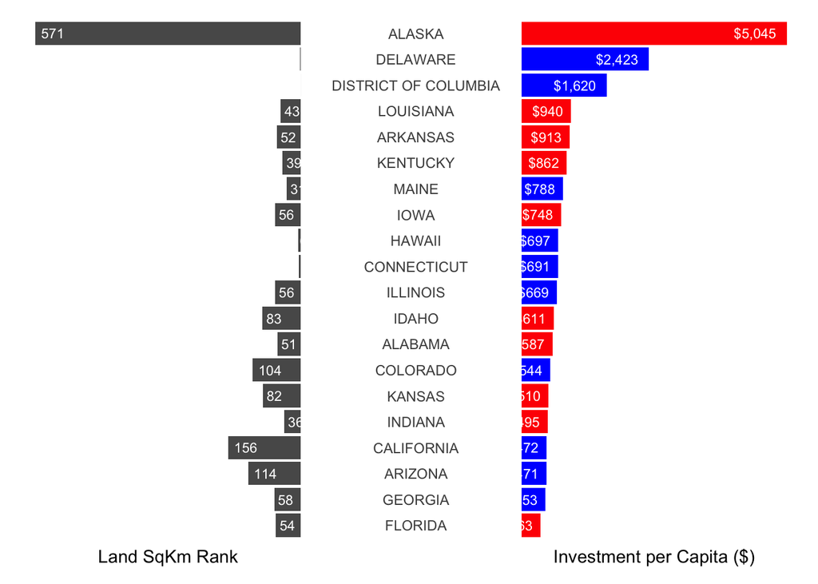

```r
area_sqkm_left <- df_top %>%
  ggplot(aes(x = region, y = -area_sqkm)) +
  geom_bar(stat = "identity", position = "identity") +
  coord_flip() +
  scale_y_continuous(labels = abs) +
  labs(x = "State", y = "Land SqKm Rank") +
  geom_text(aes(label = round(area_sqkm/1000,0)),
            color='white', position = position_nudge(y = 3), hjust = -0.25, size=3) +
  theme_minimal() +
  theme(
    plot.title = element_blank(),
    axis.text.x = element_blank(),
    axis.title.y = element_blank(),
    axis.text.y = element_blank(),
    panel.grid.major = element_blank(),
    panel.grid.minor = element_blank(),
    legend.position = 'none'
  )

area_sqkm_left + inv_rank_right
```

## Sources

2020 US Presidential Election Results https://www.presidency.ucsb.edu/statistics/elections/2020

Population by State - US Census https://www.census.gov/data/tables/time-series/demo/popest/2020s-state-total.html

Poverty Levels by State - US Census https://www.census.gov/topics/income-poverty/poverty.html

Area by State - US Census https://www.census.gov/geographies/reference-files/2010/geo/state-area.html